# Assignment

## Question 1

One class has the following letter grade rules:

- 𝑠𝑐𝑜𝑟𝑒<60 : F
- 60≤𝑠𝑐𝑜𝑟𝑒<70 : D
- 70≤𝑠𝑐𝑜𝑟𝑒<80 : C
- 80≤𝑠𝑐𝑜𝑟𝑒<90 : B
- 𝑠𝑐𝑜𝑟𝑒≥90 : A

Also, the scores used for final letter grades are curved by adding 8% of the original final score at the end of the semester.

1. Write a function to covert the original score to the final letter grade.
2. Check the letter grade for the following two cases:
- What would be the letter grade whose original score was 78?
- What would be the letter grade whose original score was 55?

```python
def score(original_score):
    result = original_score + original_score * 0.08

    if result > 90 :
        print("A")
    elif 80 < result < 90:
        print("B")
    elif 70 < result < 80:
        print("C")
    elif 60 < result < 70:
        print("D")
    else:
        print("F")

score(78)
score(55)
```

```
B
F
```

## Question 2

The partial sums of the harmonic series is $H_k=\Sigma_{n=1}^k \frac{1}{𝑛}=1+\frac{1}{2}+\frac{1}{3}+\cdots+\frac{1}{k}$.

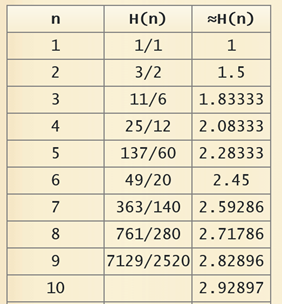

1. Write a function that finds the minimum $k$ such that $H_k\geq S$ for a given $S$. For example, for $S=2$, then the function will return 4. Also, for $S=2.5$, the function will return 7.
2. Check the result with the cases of $S=3$ and $S=3.5$.

```python
def mini_k(k):
    result_s = 0
    for i in range(1, k + 1):
        result_s += 1 / i
    return result_s

def result(s):
    k = 1
    while mini_k(k) <= s:
        k += 1
    return k


print(result(3))
print(result(3.5))
```

```
11
19
```

# Question 3

We have the following product descriptions.

```python
rucksack1 = "Rucksack. Leather and polyester. Dimensions: 18'' tall x 12'' wide x 5'' deep. Brown or black."
rucksack2 = "Classic Leather Backpack for Man. Dim: height 17'' & width 18'' & depth 8''."
```

1. Write the function(s) that returns three numbers of given the description. In the function(s) plese use for() and isdigit() to find three numbers and use append() to save them as one list.
- isdigit() returns True if the characters in the texts are digits (https://www.w3schools.com/python/ref_string_isdigit.asp).
2. Test the function(s) with the given two product descriptions.

```python
rucksack1 = "Rucksack. Leather and polyester. Dimensions: 18'' tall x 12'' wide x 5'' deep. Brown or black."
rucksack2 = "Classic Leather Backpack for Man. Dim: height 17'' & width 18'' & depth 8''."

def f_num(rucksack):
    x = rucksack.replace("'", "").replace(".", "")
    s_word = x.split()
    digits = []
    for n in s_word:
        if n.isdigit():
            digits.append(n)

    print(digits)


f_num(rucksack1)
f_num(rucksack2)

print(type(f_num(rucksack1)))
```

```
['18', '12', '5']
['17', '18', '8']
['18', '12', '5']
<class 'NoneType'>
```

# Quesiton 4

Would the function in Question 3 work for the description below? If it does not work, why would that be?

```python
rucksack3 = "Multi-purpose clear backpack. Size: 15.8 by 12.9 by 8.4 (inch)."
```

```python
rucksack3 = "Multi-purpose clear backpack. Size: 15.8 by 12.9 by 8.4 (inch)."

def f_num(rucksack):
    x = rucksack.replace("'", "")
    s_word = x.split()
    digits = []
    for n in s_word:
        if n.isdigit():
            digits.append(n)

    print(digits)


f_num(rucksack3)

# No the function is not work with rucksack3. when I debugged x and s_work, it was still working
# but it disappeared when it went through the isdight. Since this happened, we can assume isdight is not available to
# recognized float number to dighit
```

```
[]
```

Write the function(s) that can also retrieve three numbers in all three product descriptions. Test the function(s) using rucksack1, rucksack2, and rucksack3.

```python
rucksack1 = "Rucksack. Leather and polyester. Dimensions: 18'' tall x 12'' wide x 5'' deep. Brown or black."
rucksack2 = "Classic Leather Backpack for Man. Dim: height 17'' & width 18'' & depth 8''."
rucksack3 = "Multi-purpose clear backpack. Size: 15.8 by 12.9 by 8.4 (inch)."

def f_num(rucksack):
    x = rucksack.replace("'", "")
    s_word = x.split()
    digits = []

    for n in s_word:
        try:
            n = float(n)
            digits.append(n)
        except ValueError:
            continue

    print(digits)

f_num(rucksack1)
f_num(rucksack2)
f_num(rucksack3)
```

```
[18.0, 12.0, 5.0]
[17.0, 18.0, 8.0]
[15.8, 12.9, 8.4]
```

# Group Discussion

Review classmates' code and provide constructive feedback, focusing on readability, efficiency, and correctness. Peer review feedback can include something you learned from the code or a suggestion for improvement.

I compared the code with Jamie after I finished mine. The first code we wrote is almost the same, but the only difference is she put the condition if the range is out of range, and I did not. other codes look similar, but they are slightly different. She told me my question 3 output still looks like a string.